# **Transferencia de Calor 2D**

## Juan David Argüello Plata

[figure not shown]

## **LÉEME**

Antes de iniciar a leer y analizar el presente trabajo, ten en cuenta que debes **esperar** a que termine de cargar la página web.

[figure not shown]

*Figura 0.* Página inicial *binder*.

Una vez *desaparezca* la página de carga (Figura 0), recuerda que los bloques de código los puedes ejecutar con el siguiente comando:

`CTRL + ENTER`

## **1. Planteamiento del Problema**

Se busca analizar, mediante métodos *analíticos* y *numéricos*, la transferencia de calor de la barra mostrada en la Figura 1.

[figure not shown]

*Figura 1.* Geometría del problema.

Se toman las siguientes suposiciones:

- Conductividad térmica constante.
- Conducción 2D.
- Generación de calor por unidad de volumen constante.
- Conducción estable (no transitoria).

Los datos del problema se pueden especificar a continuación.

```python
data = {
    'Geometría': {
        'W': {
            'Valor':10,
            'Units': 'm'
        },
        'H': {
            'Valor': 10,
            'Units': 'm'
        },
        'E': {
            'Valor': 1,
            'Units': 'm'
        }
    },
    'Propiedades': {
        'T_0': {
            'Valor': 100+273,
            'Units': 'K'
        },
        'T_{infty}': {
            'Valor': 0+273,
            'Units': 'K'
        },
        'K': {
            'Valor': 55,
            'Units': 'W/m \, K'
        },
        'h': {
            'Valor': 10,
            'Units': 'W/m^2 \, °C'
        },
        'Q_g': {
            'Valor': 100,
            'Units': 'W/m^3'
        }
    }
}

from IPython.display import HTML, display
for c in data:
    for d in data[c]:
        text = '$' + d + '= ' + str(data[c][d]['Valor']) + '' + data[c][d]['Units'] + '$'
        display(HTML(text))
```

$W= 10m$

$H= 10m$

$E= 1m$

$T_0= 373K$

$T_{infty}= 273K$

$K= 55W/m \, K$

$h= 10W/m^2 \, °C$

$Q_g= 100W/m^3$

```python
from sympy import init_session
init_session(use_latex=True)
```

```
IPython console for SymPy 1.4 (Python 3.7.4-32-bit) (ground types: python)

These commands were executed:
>>> from __future__ import division
>>> from sympy import *
>>> x, y, z, t = symbols('x y z t')
>>> k, m, n = symbols('k m n', integer=True)
>>> f, g, h = symbols('f g h', cls=Function)
>>> init_printing()

Documentation can be found at https://docs.sympy.org/1.4/
```

## **2. Mallado**

Se inicia realizando la discretización del dominio.

```python
%matplotlib inline
from App.Preprocessing.Mesh import Malla
import sqlite3 as sql
from ipywidgets import *
def Mesh(xsub,ysub, numN = False):
    Malla((data['Geometría']['W']['Valor']/xsub,
           data['Geometría']['H']['Valor']/ysub),
           (data['Propiedades']['T_0']['Valor'],
            data['Propiedades']['T_{infty}']['Valor']),
           False,
           (numN, False),
           data['Geometría'])
    #Conexión con base de datos
    con = sql.connect('App/data.db')
    text = ["SELECT * FROM ", " ORDER BY ", " DESC LIMIT 1"]
    n =  con.execute(text[0]+' nodes '+text[1]+' NodeID '+text[2]).fetchall()
    el = con.execute(text[0]+' elements '+text[1]+' ElID '+text[2]).fetchall()
    con.close()
    display(HTML("Número de nodos: " + str(n[0][0])))
    display(HTML("Número de elementos: " + str(el[0][0])))
    return data['Geometría']['W']['Valor']/xsub, data['Geometría']['H']['Valor']/ysub, xsub, ysub
ElData = interactive(Mesh,
                     xsub=(3,20,1),
                     ysub=(3,20,1),
                     numN = False,
                     continous_update=False)
display(ElData)
```

```python
ElData
```

## **3. Solver**

El planteamiento matricial se desarrolla con base en las siguietes relaciones matemáticas: $$ \begin{equation} a_p T_p = a_E T_E + a_W T_W + a_N T_N + a_S T_S + Q_g \Delta x \Delta y \tag{3} \label{Ts} \end{equation} $$ Dónde $b$ es la generación de calor y: $$ \begin{equation} a_p = a_E + a_W + a_N + a_S \\ a_E = K \frac{\Delta y}{\delta x} \\ a_W = K \frac{\Delta y}{\delta x} \\ a_N = K \frac{\Delta x}{\delta y} \\ a_S = K \frac{\Delta x}{\delta y} \end{equation} $$ Para la malla mostrada anteriormente, el sistema de ecuaciones general es el siguiente:

```python
#Lectura de la base de datos
con = sql.connect('App/data.db')
nodos = con.execute("SELECT * FROM nodes ORDER BY ID ASC").fetchall()
elementos = con.execute("SELECT * FROM elements ORDER BY p ASC").fetchall()
con.close()
#Símbolos
Ts = symbols("T_1:" + str(len(nodos)+1))
a_p, a_E, a_W, a_S, a_N, Q_g = symbols("a_p, a_E, a_W, a_S, a_N, Q_g")
Dx, Dy, dx, dy = Symbol("\\Delta  x"), Symbol("\\Delta  y"), Symbol("\\delta  x"), Symbol("\\delta  y")
#Planteamiento de ecuaciones y suposiciones
Ecuaciones = []
sol = {}
conocidas = {}
suma = 0
for i in range(len(nodos)):
    if nodos[i][-1] is None:
        Ec = Eq(a_p*Ts[elementos[suma][3]-1],a_E*Ts[elementos[suma][4]-1]+\
                a_W*Ts[elementos[suma][5]-1]+a_N*Ts[elementos[suma][1]-1]+\
                a_S*Ts[elementos[suma][2]-1]+Q_g*Dx*Dy)
        sol[Ts[elementos[suma][3]-1]] = solve(Ec, Ts[elementos[suma][3]-1])[0]
        suma += 1
    else:
        Ec = Eq(Ts[i], nodos[i][-1])
        conocidas[Ts[i]] = solve(Ec)[0]
    Ecuaciones.append(Ec)
sup = {}
for el in elementos:
    sup[Ts[el[3]-1]] = 0
Ecuaciones
```

$\displaystyle \left[ T_{1} = 273.0, \ T_{2} = 273.0, \ T_{3} = 273.0, \ T_{4} = 273.0, \ T_{5} = 273.0, \ T_{6} = 273.0, \ T_{7} a_{p} = Q_{g} \Delta x \Delta y + T_{1} a_{W} + T_{14} a_{E} + T_{6} a_{S} + T_{8} a_{N}, \ T_{8} a_{p} = Q_{g} \Delta x \Delta y + T_{15} a_{E} + T_{2} a_{W} + T_{7} a_{S} + T_{9} a_{N}, \ T_{9} a_{p} = Q_{g} \Delta x \Delta y + T_{10} a_{N} + T_{16} a_{E} + T_{3} a_{W} + T_{8} a_{S}, \ T_{10} a_{p} = Q_{g} \Delta x \Delta y + T_{11} a_{N} + T_{17} a_{E} + T_{4} a_{W} + T_{9} a_{S}, \ T_{11} a_{p} = Q_{g} \Delta x \Delta y + T_{10} a_{S} + T_{12} a_{N} + T_{18} a_{E} + T_{5} a_{W}, \ T_{12} = 373.0, \ T_{13} = 273.0, \ T_{14} a_{p} = Q_{g} \Delta x \Delta y + T_{13} a_{S} + T_{15} a_{N} + T_{21} a_{E} + T_{7} a_{W}, \ T_{15} a_{p} = Q_{g} \Delta x \Delta y + T_{14} a_{S} + T_{16} a_{N} + T_{22} a_{E} + T_{8} a_{W}, \ T_{16} a_{p} = Q_{g} \Delta x \Delta y + T_{15} a_{S} + T_{17} a_{N} + T_{23} a_{E} + T_{9} a_{W}, \ T_{17} a_{p} = Q_{g} \Delta x \Delta y + T_{10} a_{W} + T_{16} a_{S} + T_{18} a_{N} + T_{24} a_{E}, \ T_{18} a_{p} = Q_{g} \Delta x \Delta y + T_{11} a_{W} + T_{17} a_{S} + T_{19} a_{N} + T_{25} a_{E}, \ T_{19} = 373.0, \ T_{20} = 273.0, \ T_{21} a_{p} = Q_{g} \Delta x \Delta y + T_{14} a_{W} + T_{20} a_{S} + T_{22} a_{N} + T_{28} a_{E}, \ T_{22} a_{p} = Q_{g} \Delta x \Delta y + T_{15} a_{W} + T_{21} a_{S} + T_{23} a_{N} + T_{29} a_{E}, \ T_{23} a_{p} = Q_{g} \Delta x \Delta y + T_{16} a_{W} + T_{22} a_{S} + T_{24} a_{N} + T_{30} a_{E}, \ T_{24} a_{p} = Q_{g} \Delta x \Delta y + T_{17} a_{W} + T_{23} a_{S} + T_{25} a_{N} + T_{31} a_{E}, \ T_{25} a_{p} = Q_{g} \Delta x \Delta y + T_{18} a_{W} + T_{24} a_{S} + T_{26} a_{N} + T_{32} a_{E}, \ T_{26} = 373.0, \ T_{27} = 273.0, \ T_{28} a_{p} = Q_{g} \Delta x \Delta y + T_{21} a_{W} + T_{27} a_{S} + T_{29} a_{N} + T_{35} a_{E}, \ T_{29} a_{p} = Q_{g} \Delta x \Delta y + T_{22} a_{W} + T_{28} a_{S} + T_{30} a_{N} + T_{36} a_{E}, \ T_{30} a_{p} = Q_{g} \Delta x \Delta y + T_{23} a_{W} + T_{29} a_{S} + T_{31} a_{N} + T_{37} a_{E}, \ T_{31} a_{p} = Q_{g} \Delta x \Delta y + T_{24} a_{W} + T_{30} a_{S} + T_{32} a_{N} + T_{38} a_{E}, \ T_{32} a_{p} = Q_{g} \Delta x \Delta y + T_{25} a_{W} + T_{31} a_{S} + T_{33} a_{N} + T_{39} a_{E}, \ T_{33} = 373.0, \ T_{34} = 273.0, \ T_{35} a_{p} = Q_{g} \Delta x \Delta y + T_{28} a_{W} + T_{34} a_{S} + T_{36} a_{N} + T_{41} a_{E}, \ T_{36} a_{p} = Q_{g} \Delta x \Delta y + T_{29} a_{W} + T_{35} a_{S} + T_{37} a_{N} + T_{42} a_{E}, \ T_{37} a_{p} = Q_{g} \Delta x \Delta y + T_{30} a_{W} + T_{36} a_{S} + T_{38} a_{N} + T_{43} a_{E}, \ T_{38} a_{p} = Q_{g} \Delta x \Delta y + T_{31} a_{W} + T_{37} a_{S} + T_{39} a_{N} + T_{44} a_{E}, \ T_{39} a_{p} = Q_{g} \Delta x \Delta y + T_{32} a_{W} + T_{38} a_{S} + T_{40} a_{N} + T_{45} a_{E}, \ T_{40} = 373.0, \ T_{41} = 273.0, \ T_{42} = 273.0, \ T_{43} = 273.0, \ T_{44} = 273.0, \ T_{45} = 273.0\right]$

Despejando las ecuaciones, se tiene:

```python
sol
```

$\displaystyle \left\{ T_{10} : \frac{Q_{g} \Delta x \Delta y + T_{11} a_{N} + T_{17} a_{E} + T_{4} a_{W} + T_{9} a_{S}}{a_{p}}, \ T_{11} : \frac{Q_{g} \Delta x \Delta y + T_{10} a_{S} + T_{12} a_{N} + T_{18} a_{E} + T_{5} a_{W}}{a_{p}}, \ T_{14} : \frac{Q_{g} \Delta x \Delta y + T_{13} a_{S} + T_{15} a_{N} + T_{21} a_{E} + T_{7} a_{W}}{a_{p}}, \ T_{15} : \frac{Q_{g} \Delta x \Delta y + T_{14} a_{S} + T_{16} a_{N} + T_{22} a_{E} + T_{8} a_{W}}{a_{p}}, \ T_{16} : \frac{Q_{g} \Delta x \Delta y + T_{15} a_{S} + T_{17} a_{N} + T_{23} a_{E} + T_{9} a_{W}}{a_{p}}, \ T_{17} : \frac{Q_{g} \Delta x \Delta y + T_{10} a_{W} + T_{16} a_{S} + T_{18} a_{N} + T_{24} a_{E}}{a_{p}}, \ T_{18} : \frac{Q_{g} \Delta x \Delta y + T_{11} a_{W} + T_{17} a_{S} + T_{19} a_{N} + T_{25} a_{E}}{a_{p}}, \ T_{21} : \frac{Q_{g} \Delta x \Delta y + T_{14} a_{W} + T_{20} a_{S} + T_{22} a_{N} + T_{28} a_{E}}{a_{p}}, \ T_{22} : \frac{Q_{g} \Delta x \Delta y + T_{15} a_{W} + T_{21} a_{S} + T_{23} a_{N} + T_{29} a_{E}}{a_{p}}, \ T_{23} : \frac{Q_{g} \Delta x \Delta y + T_{16} a_{W} + T_{22} a_{S} + T_{24} a_{N} + T_{30} a_{E}}{a_{p}}, \ T_{24} : \frac{Q_{g} \Delta x \Delta y + T_{17} a_{W} + T_{23} a_{S} + T_{25} a_{N} + T_{31} a_{E}}{a_{p}}, \ T_{25} : \frac{Q_{g} \Delta x \Delta y + T_{18} a_{W} + T_{24} a_{S} + T_{26} a_{N} + T_{32} a_{E}}{a_{p}}, \ T_{28} : \frac{Q_{g} \Delta x \Delta y + T_{21} a_{W} + T_{27} a_{S} + T_{29} a_{N} + T_{35} a_{E}}{a_{p}}, \ T_{29} : \frac{Q_{g} \Delta x \Delta y + T_{22} a_{W} + T_{28} a_{S} + T_{30} a_{N} + T_{36} a_{E}}{a_{p}}, \ T_{30} : \frac{Q_{g} \Delta x \Delta y + T_{23} a_{W} + T_{29} a_{S} + T_{31} a_{N} + T_{37} a_{E}}{a_{p}}, \ T_{31} : \frac{Q_{g} \Delta x \Delta y + T_{24} a_{W} + T_{30} a_{S} + T_{32} a_{N} + T_{38} a_{E}}{a_{p}}, \ T_{32} : \frac{Q_{g} \Delta x \Delta y + T_{25} a_{W} + T_{31} a_{S} + T_{33} a_{N} + T_{39} a_{E}}{a_{p}}, \ T_{35} : \frac{Q_{g} \Delta x \Delta y + T_{28} a_{W} + T_{34} a_{S} + T_{36} a_{N} + T_{41} a_{E}}{a_{p}}, \ T_{36} : \frac{Q_{g} \Delta x \Delta y + T_{29} a_{W} + T_{35} a_{S} + T_{37} a_{N} + T_{42} a_{E}}{a_{p}}, \ T_{37} : \frac{Q_{g} \Delta x \Delta y + T_{30} a_{W} + T_{36} a_{S} + T_{38} a_{N} + T_{43} a_{E}}{a_{p}}, \ T_{38} : \frac{Q_{g} \Delta x \Delta y + T_{31} a_{W} + T_{37} a_{S} + T_{39} a_{N} + T_{44} a_{E}}{a_{p}}, \ T_{39} : \frac{Q_{g} \Delta x \Delta y + T_{32} a_{W} + T_{38} a_{S} + T_{40} a_{N} + T_{45} a_{E}}{a_{p}}, \ T_{7} : \frac{Q_{g} \Delta x \Delta y + T_{1} a_{W} + T_{14} a_{E} + T_{6} a_{S} + T_{8} a_{N}}{a_{p}}, \ T_{8} : \frac{Q_{g} \Delta x \Delta y + T_{15} a_{E} + T_{2} a_{W} + T_{7} a_{S} + T_{9} a_{N}}{a_{p}}, \ T_{9} : \frac{Q_{g} \Delta x \Delta y + T_{10} a_{N} + T_{16} a_{E} + T_{3} a_{W} + T_{8} a_{S}}{a_{p}}\right\}$

### 3.1. Solución mediante *Gauss - Seidel*

*Gauss - Seidel* plantea una metodología de solución y comprobación iterativa. Se parte de la solución "trivial" como punto de partida.

```python
sup
```

$\displaystyle \left\{ T_{10} : 0, \ T_{11} : 0, \ T_{14} : 0, \ T_{15} : 0, \ T_{16} : 0, \ T_{17} : 0, \ T_{18} : 0, \ T_{21} : 0, \ T_{22} : 0, \ T_{23} : 0, \ T_{24} : 0, \ T_{25} : 0, \ T_{28} : 0, \ T_{29} : 0, \ T_{30} : 0, \ T_{31} : 0, \ T_{32} : 0, \ T_{35} : 0, \ T_{36} : 0, \ T_{37} : 0, \ T_{38} : 0, \ T_{39} : 0, \ T_{7} : 0, \ T_{8} : 0, \ T_{9} : 0\right\}$

Reemplazando los datos correspondientes, se obtiene...

```python
#Variables
var = {}
var['Q_g'], var['K'] = data['Propiedades']['Q_g']['Valor'], data['Propiedades']['K']['Valor']
var['Dx'], var['Dy'], nodosx, nodosy = ElData.result
nodosx += 2
nodosy += 2
#a's
for a in ['a_E', 'a_W']:
    var[a] = var['K']*(var['Dy']/var['Dx'])
for a in ['a_S', 'a_N']:
    var[a] = var['K']*(var['Dx']/var['Dy'])
var['a_p'] = 0    #Es 0 porque es conducción pura, rho*u (densidad por velocidad)
for a in ['a_E', 'a_W', 'a_S', 'a_N']:
    var['a_p'] += var[a]
#Diccionario de variables
var_sup = {}
for key in [Q_g, a_E, a_W, a_S, a_N, a_p]:
    var_sup[key] = var[f"{key}"]
var_sup[Dx], var_sup[Dy] = var['Dx'], var['Dy']
#Reemplazar
solution = {}
protected = frozenset(sol.items())
for s in sol:
    solution[s] = dict(protected)[s].subs(var_sup)
    solution[s] = solution[s].subs(conocidas)
solution
```

$\displaystyle \left\{ T_{10} : 0.25 T_{11} + 0.25 T_{17} + 0.25 T_{9} + 70.0681818181818, \ T_{11} : 0.25 T_{10} + 0.25 T_{18} + 163.318181818182, \ T_{14} : 0.25 T_{15} + 0.25 T_{21} + 0.25 T_{7} + 70.0681818181818, \ T_{15} : 0.25 T_{14} + 0.25 T_{16} + 0.25 T_{22} + 0.25 T_{8} + 1.81818181818182, \ T_{16} : 0.25 T_{15} + 0.25 T_{17} + 0.25 T_{23} + 0.25 T_{9} + 1.81818181818182, \ T_{17} : 0.25 T_{10} + 0.25 T_{16} + 0.25 T_{18} + 0.25 T_{24} + 1.81818181818182, \ T_{18} : 0.25 T_{11} + 0.25 T_{17} + 0.25 T_{25} + 95.0681818181818, \ T_{21} : 0.25 T_{14} + 0.25 T_{22} + 0.25 T_{28} + 70.0681818181818, \ T_{22} : 0.25 T_{15} + 0.25 T_{21} + 0.25 T_{23} + 0.25 T_{29} + 1.81818181818182, \ T_{23} : 0.25 T_{16} + 0.25 T_{22} + 0.25 T_{24} + 0.25 T_{30} + 1.81818181818182, \ T_{24} : 0.25 T_{17} + 0.25 T_{23} + 0.25 T_{25} + 0.25 T_{31} + 1.81818181818182, \ T_{25} : 0.25 T_{18} + 0.25 T_{24} + 0.25 T_{32} + 95.0681818181818, \ T_{28} : 0.25 T_{21} + 0.25 T_{29} + 0.25 T_{35} + 70.0681818181818, \ T_{29} : 0.25 T_{22} + 0.25 T_{28} + 0.25 T_{30} + 0.25 T_{36} + 1.81818181818182, \ T_{30} : 0.25 T_{23} + 0.25 T_{29} + 0.25 T_{31} + 0.25 T_{37} + 1.81818181818182, \ T_{31} : 0.25 T_{24} + 0.25 T_{30} + 0.25 T_{32} + 0.25 T_{38} + 1.81818181818182, \ T_{32} : 0.25 T_{25} + 0.25 T_{31} + 0.25 T_{39} + 95.0681818181818, \ T_{35} : 0.25 T_{28} + 0.25 T_{36} + 138.318181818182, \ T_{36} : 0.25 T_{29} + 0.25 T_{35} + 0.25 T_{37} + 70.0681818181818, \ T_{37} : 0.25 T_{30} + 0.25 T_{36} + 0.25 T_{38} + 70.0681818181818, \ T_{38} : 0.25 T_{31} + 0.25 T_{37} + 0.25 T_{39} + 70.0681818181818, \ T_{39} : 0.25 T_{32} + 0.25 T_{38} + 163.318181818182, \ T_{7} : 0.25 T_{14} + 0.25 T_{8} + 138.318181818182, \ T_{8} : 0.25 T_{15} + 0.25 T_{7} + 0.25 T_{9} + 70.0681818181818, \ T_{9} : 0.25 T_{10} + 0.25 T_{16} + 0.25 T_{8} + 70.0681818181818\right\}$

Ahora, se desarrolla el procedimiento iterativo. Se plantea un criterio de convergencia que defina la *culminación* del proceso de cálculo.

```python
from IPython.display import HTML, display
con.close()
#----Criterio de convergencia----
CC = 0.01
max_it = 20    #Número máximo de iteraciones

#--Solución mediante Gauss - Seidel--
criterion = 1.1
it = 0
protected = frozenset(solution.items())
protected_sup = frozenset(sup.items())
while True:
    if criterion <= CC or it >= max_it:
        display(HTML("Iteración número $" + str(it) + "$. Máximo valor de error: $" \
                     + str(round(criterion*100,2)) + "\%$"))
        break
    it += 1
    if it == 1:
        viejo = dict(protected_sup)
    #Reemplaza con valores anteriores
    nuevo = {}
    maximo = -1
    T_max = data['Propiedades']['T_{infty}']['Valor']
    for key in sol:
        nuevo[key] = dict(protected)[key].subs(viejo)
        porcentaje = abs((nuevo[key]-viejo[key])/nuevo[key])
        viejo[key] = nuevo[key]
        if T_max < nuevo[key]:
            T_max = nuevo[key]
        if maximo < porcentaje:
            maximo = porcentaje
    criterion = maximo
Temps = {**nuevo, **conocidas}
#Actualización de la base de datos nodales
con = sql.connect('App/data.db')
for i in range(len(nodos)):
    if nodos[i][4] is None:
        con.execute("UPDATE nodes SET T =" + str(Temps[Ts[i]]) + " WHERE ID =" + str(i+1))
nodos = con.execute("SELECT * FROM nodes ORDER BY ID ASC").fetchall()
con.close()
Temps
```

Iteración número $15$. Máximo valor de error: $0.84\%$

$\displaystyle \left\{ T_{1} : 273.0, \ T_{10} : 304.03043330264, \ T_{11} : 324.925183322163, \ T_{12} : 373.0, \ T_{13} : 273.0, \ T_{14} : 283.592390421326, \ T_{15} : 293.121235601425, \ T_{16} : 304.716906625861, \ T_{17} : 320.733927002726, \ T_{18} : 343.331840033294, \ T_{19} : 373.0, \ T_{2} : 273.0, \ T_{20} : 273.0, \ T_{21} : 285.353160852196, \ T_{22} : 296.446509431081, \ T_{23} : 309.415855199061, \ T_{24} : 326.386851256096, \ T_{25} : 348.330365669921, \ T_{26} : 373.0, \ T_{27} : 273.0, \ T_{28} : 284.82597673848, \ T_{29} : 294.977269357542, \ T_{3} : 273.0, \ T_{30} : 306.577578493328, \ T_{31} : 322.131784226452, \ T_{32} : 344.031388489549, \ T_{33} : 373.0, \ T_{34} : 273.0, \ T_{35} : 281.188339657226, \ T_{36} : 287.588356354292, \ T_{37} : 294.84964947161, \ T_{38} : 305.661209439972, \ T_{39} : 325.741331300562, \ T_{4} : 273.0, \ T_{40} : 373.0, \ T_{41} : 273.0, \ T_{42} : 273.0, \ T_{43} : 273.0, \ T_{44} : 273.0, \ T_{45} : 273.0, \ T_{5} : 273.0, \ T_{6} : 273.0, \ T_{7} : 279.749783127823, \ T_{8} : 285.423560852046, \ T_{9} : 292.679141933532\right\}$

## **4. Postprocesamiento**

La distribución de temperatura se puede apreciar a continuación.

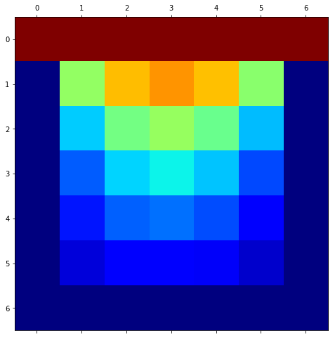

```python
import numpy as np
Temp = []
for nodo in nodos:
    if nodo[4] != data['Propiedades']['T_{infty}']['Valor'] and nodo[4] != data['Propiedades']['T_0']['Valor']:
        Temp.append(nodo[4])
#Valores de frontera
T = np.zeros((nodosx, nodosy))
for i in range(nodosx):
    for j in range(nodosy):
        if j == nodosy-1 or j == 0 or i == nodosx-1:
            T[i][j] = data['Propiedades']['T_{infty}']['Valor']
        if i == 0:
            T[i][j] = data['Propiedades']['T_0']['Valor']
k = 0
#Resultados intermedios
for j in range(nodosy-1,-1,-1):
    for i in range(nodosx-1,-1,-1):
        if T[i][j] == 0:
            T[i][j] = Temp[k]
            k += 1
plt.figure(figsize=(8,8))
plt.matshow(T, cmap=plt.cm.get_cmap('jet'), fignum=1)
```